# A three-layer analysis of the English dative alternation

SLE 58, Bordeaux, 26–29 August 2025

L. De Cuypere (VUB & UGent) & K. Willems (UGent)

## Overview

- English dative alternation
  - isomorphism vs. optionality
  - probabilistic approach
- German ditransitive alternation
  - English vs. German
  - three-layer approach: system - norm - utterance
  - encoded meaning vs. inferred interpretation
- English dative alternation revisited

# English dative alternation

## Optionality

- Katz-Postal (1964) hypothesis:
  - transformations do not alter the meaning.
  - both alternants (surface structures) are derived from the same deep structure. (i.e., there is a “shift” in form, not in meaning.)
- One Constructeme – Two allostructions (Perek 2015).

## Two allostructions (Perek 2015)

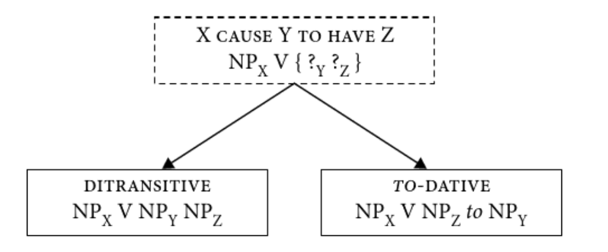

Source: Perek 2015: 256, Figure 6.2.

> [G]eneralizations of a common meaning over several constructions, associated with an underspecified form.

(Perek 2015: 51)

## Isomorphism

2. 1. Mary taught John linguistics.
   2. Mary taught linguistics to John.
- Green (1974: 157):
  - 1. implies that John learned linguistics.
  - 2. is neutral/agnostic to this matter.

## More semantic-pragmatic differences…

- to-prep construction emphasises the path, DOC the completion of the transfer (Langacker 1991)
- DOC emphasizes (the effect on) the recipient, the to-prep construction emphasized (the effect on) the patient/the object being transfered (e.g., Wierzbicka 1975).
- Closeness is strength of effect: DOC implies succesful transfer (Lakoff & Johnson 1980).
- “greater or lesser syntactic distance between verb and beneficiary corresponds to a greater of lesser degree of personal involvement” (Rohdenburg 2003: 266).
- “causing a change of state” (possession)” vs. “causing a change of place” (movement) (Pinker 1989).

## Problem

- Is the semantic difference encoded in the grammar or a matter of interpretation in language use?

## Corpus data (Bresnan et al. 2007)

3. Why not just give them cheques?’ I asked. “You can’t give cheques to people. It would be insulting.”<sup>1</sup>
4. This life-sized prop will give the creeps to just about anyone!<sup>2</sup>
5. As player A pushed him the chips, all hell broke loose at the table.<sup>3</sup>
[^1]: different construction in the same cotext
[^2]: unidiomatic, DOC expected
[^3]: to-prep construction expected

## Probabilistic approach

- The biggest methodological success story of the past decades.
- Based on a triangulation of:
  - Corpus data
  - Statistical modelling; Machine/Deep Learning
  - Judgement experiments (100-split task)
- We have **conclusive evidence** that morphosyntactic alternations are associated with multiple factors (extralinguistic factors, properties of Theme/Recipient, the meaning/sense class of the sentence verb).<sup>1</sup>
[^4]: “modelled” does not mean that we have a full explanation of how the speaker creates/generates/choses language – a statistical model is not a generative model.

## Remaining issues…

- The probabilistic approach is rather agnostic about the ontological status of constructions (constructemes/allostructions/horizontal/vertical links).
- Basic theoretical assumptions:
  - Probabilistic tendencies are part of the linguistic competence of the speaker.
  - Separate factors have been associated with overall (latent) constructs, incl. Harmonic Alignment (Bresnan et al. 2007), Topicworthiness (Thompson 1995), and Information flow (Bresnan & Ford 2010).

## Challenge

- How to reconcile the (alleged) semantic difference(s) with the probabilistic tendencies?
- Semantic-pragmatic differences are relatively straightforward to observe in constructed examples but harder to detect in corpus data, where speakers’ intentions are often unrecoverable.
- That a distinction is hard to annotate does not imply that it does not exist.

## Dative alternation: isomorphism vs. optionality

1. Two constructions: semantically synonymous, but pragmatically different (Goldberg 1995: 69):
   - DOC: NP V NP NP: ‘caused possession’/‘X causes Y to receive Z’
   - to-prep construction: NP V NP PP: ‘(transfer) caused motion’/‘X causes Y to move Z’ (expresses ‘transfer’ through metaphorical extension and is accordingly synonymous with ‘caused transfer’)
   - Probabilistic preferences between the two constructions are pragmatic differences.
2. One construction/constructeme with two allostructions. (Perek 2015)

## Challenge

- What is the most adequate analysis?
- We argue that the choice between “isomorphism” and “optionality” is a false dichotomy.

# German ditransitive alternation

## German ditransitive alternation<sup>1</sup>

6. 1. Er schickt <seiner Mutter> [einen Brief].<sup>2</sup>
   2. Er schickt [einen Brief] <an seine Mutter>.<sup>3</sup>
[^5]: For a more detailed outline of the German ditransitive alternation see also(Willems 2020; Willems & Munteanu 2021; Willems, Van Damme & De Vaere 2025)
[^6]: ‘He sends his mother a letter.’. All German examples are drawn from the Deutsches Referenzkorpus (IDS Mannheim)
[^7]: ‘He sends a letter to his mother.’

## More examples

#### IOC

7. Der Besuch hat <ihm> [Energie] gegeben.
8. Die schicken <uns> nur noch [Terroristen].
9. Die Angestellten übergaben [ihn] <der Polizei>.<sup>1</sup>

#### POC

10. Niemals wird [das Geld]> <an die Familien> gegeben.
11. Er schickt [einen Brief]> <an die Jury>.
12. Sie gibt [ihr Mandat]> <an Rolf Scharringhausen> ab.<sup>2</sup>
[^8]: The visit gave <him> [energy]; They only send <us> [terrorists]; The employees turned [him] over to <the police>.
[^9]: [The money] is never given <to the families>. He sends [a letter] <to the jury>; She gives [her mandate] <to Rolf Scharringhausen>.

## German vs. English: Differences

#### 1. Formal differences

- Difference in alignment (Bickel 2011):
  - English: neutral + indirective alignment
  - German: indirective alignment

#### 2. Semantic difference

- DOC/IOC: Animacy reading is stronger in English than in German.

#### 3. German: POC is not a caused motion construction

## Formal difference: No DOC in German

The Rec is consistently marked differently from Theme:

13. 1. Ich schickte der Dame [ein Buch].<sup>1</sup> (der Dame = dative)
    2. Ich kann die Dame sehen.<sup>2</sup> (die Dame = accusative)
14. 1. Ich schickte ein Buch **an** die Dame.<sup>3</sup>
    2. Ich kann [die Dame] sehen.<sup>4</sup>
[^10]: ‘I sent the lady a book’
[^11]: ‘I can see the lady’
[^12]: ‘I sent a book to the lady’
[^13]: ‘I can see the lady’

## German: no animacy constraint

- The Indirect Object can also be a place, concrete or abstract object, body part, etc.:
15. Sie gaben dem Haus einen Namen.<sup>1</sup>
16. der Geschichte eine Überschrift geben.<sup>2</sup>
17. dem Fernseher ein Vollbild senden.<sup>3</sup>
18. Diese Abteilungen schicken der Klinik die meisten Patienten.<sup>4</sup>
19. [Die längste Hängebrücke der Welt] ist gestern in Japan <dem Verkehr> übergeben worden.<sup>5</sup>
[^14]: ‘They gave the house a name.’
[^15]: ‘to give the story a title.’
[^16]: ‘send the tv a message.’
[^17]: ‘These departments send the clinic the most patients.’
[^18]: ‘The longest suspension bridge in the world was opened **to** traffic in Japan yesterday.’

## POC vs. Caused Motion in German

20. Ich schickte ein Buch **an die Dame**.<sup>1</sup>
21. 1. Er hängte das Bild **an die Wand**. (acc - motion)<sup>2</sup>
    2. Das Bild hängt **an der Wand**. (dat - location)<sup>3</sup>
[^19]: ‘I sent a book to the lady’
[^20]: “He hung the picture on the wall.”
[^21]: “The picture hangs on the wall.”

## English vs. German

- In English, the formal difference between DOC and to-prep construction is different than between IOC and POC in German. (alignment difference)
- In German, the pattern [V NP + spatial PP] is formally as well as semantically distinct from the POC pattern [V NP an-PP].
- German IOC: the animacy constraint appears to be less strong than in English.

## Three-layer model

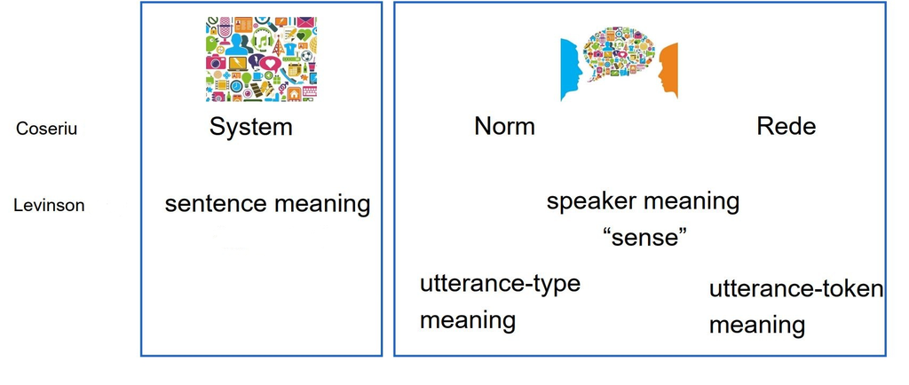

## Encoded meaning vs. Inferred meaning

- Basic ideas:
  - speakers “express”/“interpret” more than what they “say”.
  - a great deal of interpretation is conventionalised, but not encoded (cf. Levinson 2000)
- **Semantics in the narrow sense** (“what you say”): meaning that is systematically encoded in the grammar of a particular language (German: “Bedeutung”)
- **Pragmatics** (“what you mean”): pragmatically enriched content in acts of discourse, texts and “language use” in general (German: “Bezeichnung”) (Coseriu 1970; Coseriu 1975).

## Encoded meaning: operationalisation

- In the Saussurean, structuralist sense, based on paradigmatic oppositions, i.e., in relation to other argument structure constructions, viz. intransitive and monotransitive sentence patterns.
- A semantic difference is encoded iff this difference corresponds to a formal difference.
- Encoded meaning of a construction is underspecified & schematic.
- language-specific (i.e., non-universal).
- operationalisation: defeasibility and/or cancellability
  - commutation test: change the form to detect a difference in meaning and vice versa)(which is arguably the closest we can get to a linguistically valid falsification of a semantic difference).

## Encoded meaning vs. Inferred interpretation

Isomorphism and Optionality are not mutually exclusive in a three-layer approach!

- isomorphism: encoded meaning (System)
- optionality: inferred interpretation (Norm)
  - Dative-NP or an-PP+Accusative in the ditransitive construction
  - aufgrund (von), außerhalb (von), mithilfe (von) etc.
  - eine Menge Menschen hat / haben den Film gesehen

## Ditransitive alternation

#### Level 1: system

- One form/construction with One encoded meaning.
- ‘Agent-Theme-Goal’.
- ‘Goal’ = “Recipient-like” (not purely as a spatial location).

## Ditransitive alternation

#### Level 2: norm

- Two variants – IOC and POC – with different senses that are not encoded.
- Probabilistic tendencies are conventionalised preferences in normal language use. - Example: the verb *übergeben* (n = 275)(De Vaere 2023)
  - in the sense of ‘ausliefern’ (deliver): *jmdn den zuständigen Stellen übergeben* > IOC more frequent than POC
  - ‘aushändigen’ (hand over): *dem Gewinner den Preis übergeben* IOC more frequent than POC
  - ‘anvertrauen’ (entrust): *sein Amt an einen Nachfolger übergeben* > POC more frequent than IOC

## Level 1: Semantics

#### Dative NP is not limited to the semantic role Recipient

22. <Die Medikamente werden> [der Klinik] per Kurier geschickt.<sup>1</sup>
23. dem Haus einen Namen geben.
24. der Klinik Patienten schicken.
25. dem Verkehr eine Brücke übergeben
[^22]: “The medications are (being) sent to the clinic by courier.”

## Level 1: Semantics

#### an-PP is not limited to the role of spatial Destination

26. So müssen alle Aktiengesellschaften […] <ihre wirtschaftlich Berechtigten> [an das Transparenzregister] mitgeteilt haben.<sup>1</sup>
- ‘Caused Possession’ and ‘Caused Motion’ are not encoded meanings but conventionalised senses.
- IOC and POC share the same encoded, indefeasible transfer meaning ‘Agent-Theme-Goal’
[^23]: “Accordingly, all joint-stock companies must have reported their beneficial owners to the Transparency Register.”

# English dative alternation revisited

## Encoded vs. inferred

27. 1. Mary taught John linguistics.
    2. Mary taught linguistics to John.
- Whether or not the teaching was more succesful in (a) can only be inferred from the context in which the sentence is used. The semantic difference is not encoded.

## to-prep construction and caused motion

- There is an obvious similarity between the to-prep construction and other prepositional constructions:<sup>1</sup>
28. Sally sneezed the napkin off the table.
29. Mary urged Bill into the house.
30. Sue let the water out of the bathtub.
31. Chris pushed the piano up the stairs.
32. They laughed the poor guy off the stage.
[^24]: examples taken from Goldberg (1995)

## Metaphorical transfer

- Transfer Caused Motion: ’Transfer of Ownerhip as Physical Transfer (Goldberg 1995: 90).
33. 1. He drives the bus to Rome.
    2. He gives the book to Mary.

## Metaphorical transfer

- In Old English, the to-prep construction was common with Verbs of Communication (De Cuypere 2013).

(cocathom2.o3: 196, 16)

God cwæð to Moysen ðæt he wolde cumin

God said to Moses that he would come

"God said to Moses that he would come"

## English DOC

#### Not only animate Recipients:

34. The music lent the party a festive air.
35. She gives the book a title.
36. give the bike a push.
37. Another time 2 of his cousins biked him a huge bag of things because he was sick and none of them had a car.
38. […] that bring the place a softness and freshness.

## English dative alternation

- DOC: transfer of possession to a(n) (animate) recipient is not an encoded meaning, but a conventionalised sense/preference.
- to-prep construction: transfer of location is not an encoded meaning, but a conventionalised sense/preference.

## English dative alternation

#### LEVEL 1 – System: isomorphism

- One construction with one meaning ‘Agent-Theme-Goal’

#### LEVEL 2 – Norm: optionality

- Two allostructions with multiple (overlapping) conventionalised senses/preferences.
- Probabilistic tendencies are conventionalised preferences in normal language use.
- Example: the verb *pay* (Bresnan & Ford 2010: 13, fn. 17)
  - *pay* in the abstract sense (*pay attention*) prefers to-prep construction
  - *pay* in the transfer sense (*pay money*) prefers DOC.

## Workshop aim & proposed solution

> We seek to examine whether common ground can be established between the principles of isomorphism and optionality

Both are theoretically compatible and empirically differentiable, provided one distinguishes encoded meaning (system) from inferred interpretation, i.e., conventionionalised senses and probabilistic preferences (norm).

## References

Bickel, Balthasar. 2011. Grammatical relations typology. In Jae Jung Song (ed.), *The Oxford handbook of linguistic typology*, 399–444. Oxford: Oxford University Press.

Bresnan, Joan, Anna Cueni, Tatiana Nikitina & Harald Baayen. 2007. Predicting the dative alternation. In Geert Bourme, Ingo Kraemer & Joost Zwarts (eds.), *Cognitive foundations of interpretation*, 69–94. Amsterdam: Royal Netherlands Academy of Science.

Bresnan, Joan & Marilyn Ford. 2010. Predicting syntax: Processing dative constructions in American and Australian varieties of English. *Language* 86(1). 186–213.

Coseriu, Eugenio. 1970. Semantik, innere Sprachform und Tiefenstruktur. *Folia Linguistica* 4. 53–63.

Coseriu, Eugenio. 1975. *Leistung und Grenzen der transformationellen Grammatik*. Tübingen: Narr.

De Cuypere, Ludovic. 2013. Debiasing semantic analysis: The case of the English preposition to. *Language Sciences* 37. 122–135.

De Vaere, Hilde. 2023. *The ditransitive alternation in present-day German: A corpus-based analysis*. Amsterdam/Philadelphia: John Benjamins.

Goldberg, Adele. 1995. *Constructions: A construction grammar approach to argument structure*. Chicago/London: University of Chicago Press.

Green, Georgia M. 1974. *Semantics and syntactic regularity*. Bloomington, IN: Indiana University Press.

Katz, Jerrold & Paul Postal. 1964. *An integrated theory of linguistic descriptions*. Cambridge, MA: MIT Press.

Lakoff, George & Mark Johnson. 1980. *Metaphors we live by*. Chicago, IL: University of Chicago Press.

Langacker, Ronald W. 1991. *Concept, image, and symbol: The cognitive basis of grammar*. Berlin: Mouton de Gruyter.

Levinson, Stephen. 2000. *Presumptive meanings. The theory of generalized conversational implicature*. Cambridge, MA: MIT Press.

Perek, Florent. 2015. *Argument structure in usage-based construction grammar: Experimental and corpus-based perspectives*. Amsterdam: John Benjamins.

Pinker, Steven. 1989. *Learnability and cognition: The acquisition of argument structure*. Cambridge, MA: MIT Press.

Rohdenburg, Günter. 2003. Aspects of grammatical iconicity in English. In Wolfgang G. Müller & Olga Fischer (eds.), *From sign to signing*, 263–285. Amsterdam: John Benjamins.

Thompson, Sandra. 1995. The iconicity of “dative shift” in English: Considerations from information flow in discourse. In M. E. Landsberg (ed.), *Syntactic iconicity and linguistic freezes: The human dimension*, 155–175. Berlin: Mouton de Gruyter.

Wierzbicka, Anna. 1975. Why “kill” does not mean “cause to die”: The semantics of action sentences. *Foundations of Language* 13. 491–528.

Willems, Klaas. 2020. Remarks on the ditransitive construction in German. *Sprachwissenschaft* 45(2). 141–180.

Willems, Klaas & Cristinel Munteanu. 2021. Introduction. In Klaas Willems & Cristinel Munteanu (eds.), *Eugenio coseriu. Past, present and future*, 1–44. Berlin/New York: De Gruyter.

Willems, Klaas, Evi Van Damme & Hilde De Vaere. 2025. Die Dativalternation im Deutschen vom Standpunkt der einzelsprachlich-funktionellen Syntax: Synchronie und Diachronie. *Zeitschrift für Germanistische Linguistik* 53(1). 215–284.